# 2022 inflation: Layoffs and Employment

# 1. Project Aims

## 1.1 Introduction

During the coronavirus pandemic, technology companies boosted hiring to keep up with rising customer demand. However the situation has changed in 2022 [1]. The global surge in energy and agricultural prices has impacted many industries. Using Singapore as an example, the precipitous rise in energy prices have a significant impact on Singapore’s manufacturing and transport services. For instance, a 92% increase in energy prices will result in cost increases of 6 percentage points for manufacturing and 13.2 percentage points for transportation services [2]. The consequential lay off of workers from industries due to this surge in price has negatively impacted many employees all across the globe in various industries, particularly Technology. I will be cross-checking this with my own set of data. I thus wanted to analyse and acquire data on the industry that most heavily impacted due to the rise in inflation, in the attempts of understanding the risks involved in joining sectors that are volatile during periods of economic crisis. Simultaneously, narrowing down to finding out the company that is affected the most in this turbulent cause of changes. Additionally, I will be acquiring dataset from LinkedIn, a popular platform primarily used for networking and career development in which I will extract findings based on the current prevailing sector in which employees can find employment, in the attempts of collating and efficiently understanding the trend and the bird’s eye view in terms of employability in this current period. I will be finding the general trend of layoffs and will eventually center on the availability of local career opportunities(Singapore) and the viable sectors that can be seeked out by the locals. To my knowledge no similar work has been done in acquiring a detailed dataset that clearly distinguishes the industry/sector and company that has been most affected in terms of layoffs and a dataset that establishes the trending industry/sector that one could seek out for.

## 1.2 Aims and objectives

I would be exploring the following in this project:

For my project proposal, my aims are to:

- Extract data from three different types of dataset(Structured, semi-structured and unstructured) via websraping, data cleaning and visualisation
- Gather data from the accumulated dataset on the number of layoffs in each industry.
- Comparison of the collected data on the number of layoffs globally via exploratory data analysis to identify trends and anomalies
- Comparison of the collected data from Linked-In on the types of jobs available
- Consider the limitations of the source and the techniques used.

## 1.3 Data

## 1.3.1 Data requirements

I will be looking at the top 15 industries that have the highest layoffs so as to compare thoroughly the effect of the inflation. Following that, I will be finding out the top 15 jobs that are up for employment in Linked-In to find out which industry is still hiring, allowing me to craft out a possible solution for the layoffs.

## 1.3.2 Choice of source

I selected Intellizence and Kaggle as my source of data due to the relevancy and verifiability. Out of all the sources checked, Intellizence and Kaggle proved to be updated and relevant to the current trend on layoffs by different industries. On the other hand, Linked-In was chosen as, besides being one of the most popular job sites [6], it consented to webscraping.These three sources allows me to demonstrate the extraction of data from 3 different types of set, structured, semi-structured and unstructured. The following information below, gives a brief introduction on the source of data and the reason for the pick.

Kaggle(Structured data set)

- A data collection site that contains huge repository of code and data.
- Access to high quality data sets
- Easily accessible

Intellizence(Semi-structured)

- Signals-as-a-Service platform that provides accurate and useful intelligence
- Monitors a variety of data sources that are 95% relevant.
- Allowed webscraping

Linked-In(Unstructured)

- One of the top job sites that has over 750 million users
- Professional
- Allowed webscraping

## 1.3.3 Limitations and constraints of the data

### 1.3.3.1 Categories were subjective for different data sets

Both the sources Intellizence and Kaggle coined different companies under different categories in the industry section. For instance, Kaggle categorised some companies like Amazon under ‘Retail’ which in general is usually branded as a company under ‘Technology’. Cisco was categorised under ‘Infrastructure’ in Kaggle and ‘Technology’ in Intellizence. These changes in categorising the company in an industry causes confusion and misdirection for users as there is no standard categorisation of companies. Thus, it was difficult to ascertain which company or industry was affected by inflation the most. As such, I had to manually search up the name of the companies to check as to which industry they most generally fall into. This allowed me to finalise the industry that had the highest layoffs.

### 1.3.3.2 Both set of data had unequal number of layoffs listed

Kaggle and Intellizence had a drastic difference in the number of layoffs listed in their website. Kaggle had 1732 layoffs listed while Intellizence had a mere 196 layoffs listed. While both datas showed the highest layoff to be in the Technology industry, the unequal number of data on layoffs might give an inaccurate result. Since Intellizence only reported 196 layoffs, the information provided could be limited in understanding other type of information such as the least number of layoffs. This could also mean that other industries could potentially take the top spot in having the highest layoffs as the number of layoffs listed is so limited. This would mean that more datasets are needed in understanding and confirming whether the top industry is in fact technology.

### 1.4 Ethical considerations

### 1.4.1 Use of data sets

There is no prohibition against webscraping in the terms and conditions of any of the websites.

Consent to use content:

- Intellizence terms and conditions stated that “customer should not intentionally or knowingly use the Services in a way that could harm Intellizence's ability to provide the Services by overloading, damaging, or otherwise interfering with that ability”.
- Since no harm is done with the data set, I can safely assume that I am following the terms and conditions.
- On the other hand, Kaggle’s terms and condition stated that “we can engage with third parties using the Services, but Kaggle has no control over such websites' content, accuracy, privacy policies or practices, or the viewpoints represented within. In addition, Kaggle will not and is unable to check, censor, or edit the content of any website or service operated by a third party. You release and hold us blameless from any and all liabilities resulting from your use of any third-party website or service by utilizing the Services.”
- Since Kaggle is a website meant for the collection of datas, and we do not use the data for the wrong ideology, I can safely assume that I am following the terms and conditions.

### 1.4.4 Potential impacts of using layoff datas

Some data usage could have detrimental effects on people or organizations, such as the continuation of harmful and false assumptions or a reduction in revenue. Because of the following factors, I have determined that the risks associated with this project and how it will use the source data are minor. This research will concentrate on analyzing just the the layoffs of industries. The aforementioned limitations of the data used in this investigation have been mentioned. Throughout the study, limitations of the methodologies employed will be explored.

```python
# Importing libraries
import requests
from bs4 import BeautifulSoup
import csv
import matplotlib.pyplot as plt
import numpy as np
import pandas  as pd
import seaborn as sns
from collections import Counter

from selenium import webdriver
import time
import pandas as pd
import os
import re
from selenium.webdriver.support.select import Select
from selenium.webdriver.support.ui import WebDriverWait
from selenium.webdriver.common.by import By
from selenium.webdriver.common.keys import Keys
from selenium.webdriver.support import expected_conditions as EC
```

This code is importing various libraries to be used in the script. The libraries being imported include:

- requests, which is used to make HTTP requests to a website
- BeautifulSoup, which is used to parse HTML documents
- csv, which is used to read and write CSV files
- matplotlib and numpy, which are used for data visualization
- pandas, which is used for data manipulation and analysis
- seaborn, which is a library built on top of matplotlib and is used for statistical data visualization
- collections, which is a built-in Python library that provides alternatives to built-in types that can be more efficient than the alternatives.
- Selenium, which is a web testing library used to automate browser activities
- os, which is a built-in library for interacting with the operating system
- re, which is a built-in library for working with regular expressions
- Select, WebDriverWait, By and Keys classes from Selenium are used for selecting elements and waiting for elements to load and handling the keyboard commands.

# Webscraping

A CSV file containing a list of URLs needs to be analyzed for this project. Before importing the file and scraping the content of the URLs, a function should be defined to scrape the data as the URLs are iterated through. Each website has different HTML, so a separate function must be written to extract the necessary information from each one. Keep in mind that web scraping will take 5-10 minutes due to a website's requirement of a 10-second crawl delay. Scraping faster will result in being banned from the website.

```python
url = requests.get('https://intellizence.com/insights/layoff-downsizing/leading-companies-announcing-layoffs-and-hiring-freezes/')

#print(r.status_code)


#print(soup.prettify())

#print(soup.title)

#print(soup.title.parent.name)

headers = {
    'User-Agent' : " Mozilla/5.0 (X11; Linux aarch64) AppleWebKit/537.36 (KHTML, like Gecko) Chrome/88.0."
}

soup = BeautifulSoup(url.content, 'html.parser')

#s = soup.find_all('div', class_='custom-table-2')
#s = soup.find_all('table', id='tablepress-63')


df = pd.DataFrame(columns=['Date', 'Company', 'Industry', 'Location', 'Layoff'])

#print(df)
for table in soup.find_all('table'):
       #print(table.get('class'))

     for row in table.tbody.find_all('tr'):
    # Find all data for each column
         columns = row.find_all('td')

         if(columns != []):
                date = columns[0].text.strip()
                company = columns[1].text.strip()
                industry = columns[2].text.strip()
                location = columns[3].text.strip()
                jobs = columns[4].text.strip()
                datas=[date,company,industry,location,jobs]
                #print(datas)

                df = df.append({'Date': date,  'Company': company, 'Industry': industry,'Location': location,'Layoff': jobs},ignore_index=True)
```

[output not shown]

[output cut: 458 more lines]

```python
#Removing the strings in Layoff Column
df['Layoff'] = df['Layoff'].str.replace(r'\D', '')
```

```python
#Removing Duplicate values based on Repeated company's
df2 = df.drop_duplicates(keep='first')
#Replacing 0 with NAN values
df2 = df2.replace(r'^\s*$', np.nan, regex=True)
df2["Layoff"]= pd.to_numeric(df2["Layoff"], errors='coerce').fillna(0)
df2
```

|  | Date | Company | Industry | Location | Layoff |
| --- | --- | --- | --- | --- | --- |
| 0 | November 2022 | United Furniture Industries | Manufacturing | USA | 0.0 |
| 1 | November 2022 | Infarm | Agri technology | Germany | 500.0 |
| 2 | November 2022 | Hirect | Business Services | India | 40.0 |
| 3 | November 2022 | Alphabet | Technology | USA | 10000.0 |
| 4 | November 2022 | HP | Technology | USA | 6000.0 |
| ... | ... | ... | ... | ... | ... |
| 237 | December 2022 | GoStudent | Edutech | Austria | 100.0 |
| 238 | December 2022 | Freshworks | SaaS Technology | USA | 90.0 |
| 239 | December 2022 | SonderMind | HealthTech | USA | 15.0 |
| 240 | December 2022 | Apollo Global Management | Private Equity | USA | 15.0 |
| 241 | December 2022 | Bigcommerce Holdings | eCommerce | USA | 13.0 |

196 rows × 5 columns

```python
#Dropping the values that are not useful due to lack of accurate data
df2.drop(df2[(df2['Layoff'] < 80)].index, inplace=True)
```

```python
# To show the type of datas used in this dataframe
df2.info()
```

```
<class 'pandas.core.frame.DataFrame'>
Int64Index: 157 entries, 1 to 238
Data columns (total 5 columns):
 #   Column    Non-Null Count  Dtype
---  ------    --------------  -----
 0   Date      157 non-null    object
 1   Company   157 non-null    object
 2   Industry  157 non-null    object
 3   Location  157 non-null    object
 4   Layoff    157 non-null    float64
dtypes: float64(1), object(4)
memory usage: 7.4+ KB
```

```python
#to shpw the details of the data
df2.describe()
```

|  | Layoff |
| --- | --- |
| count | 157.000000 |
| mean | 1828.509554 |
| std | 3852.991378 |
| min | 82.000000 |
| 25% | 350.000000 |
| 50% | 500.000000 |
| 75% | 1300.000000 |
| max | 35010.000000 |

```python
# Storing the current data in CSV Format for duture use
df2.to_csv('raw1_data.csv', index=False)
```

```python
# Reading from the saved data file
data = pd.read_csv(r'raw1_data.csv')
data
```

[output not shown]

145 rows × 5 columns

```python
# Changing the spelling in the columns due to spelling mistake and wrong punctuation has been used
data['Industry']= data['Industry'].replace("e-Commerce", "ECommerce")
data['Industry']= data['Industry'].replace("Technolgy", "Technology")
data['Industry']= data['Industry'].replace("Financial Services", "FinancialServices")
```

```python
#Groupby Industry and Showing the sum of layoffs by each industry
grouped = data.groupby('Industry')
group_industry=grouped['Layoff'].agg(np.sum)
group_industry=group_industry.sort_values(ascending=False)

group_industry.head(10)
```

```
Industry
Technology           80129.0
Edtech               35434.0
ECommerce            26458.0
Manufacturing        20653.0
FinancialServices    17160.0
Transportation       10670.0
Logistics            10650.0
Automotive            9400.0
Retail                6740.0
Entertainment         5300.0
Name: Layoff, dtype: float64
```

```python
focus = data[["Industry","Layoff"]].sort_values(by=['Layoff'], ascending=False)
topfocus = focus.head(50)
```

This code is sorting the dataframe "data" based on the "Layoff" column in descending order and selecting the top 50 rows of the sorted dataframe. The resulting dataframe, named "topfocus", will contain the top 50 rows of data that have the highest values in the "Layoff" column. It is also only taking Industry and Layoff Columns from the original dataframe 'data' and creating a new dataframe 'focus'.

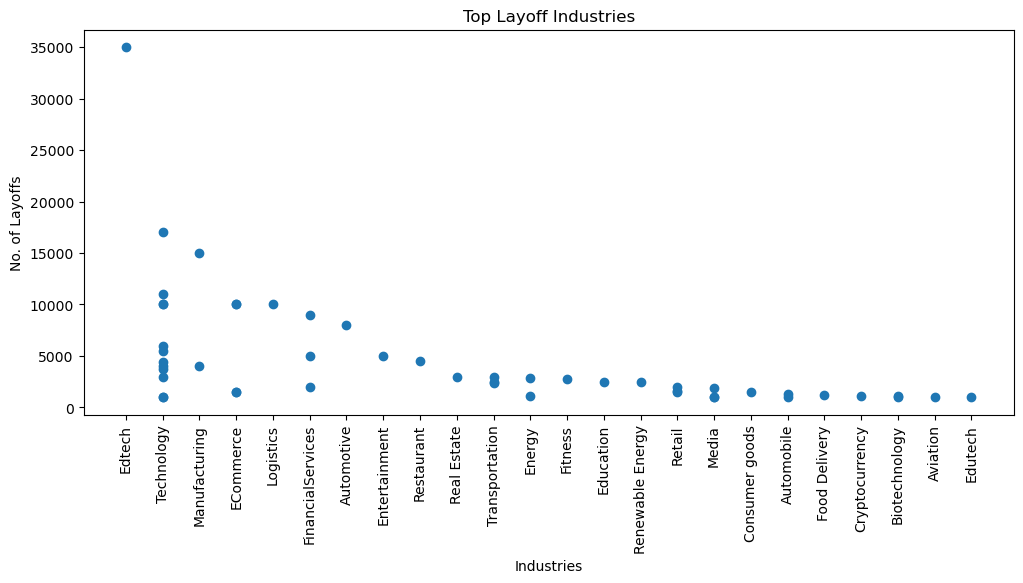

```python
plt.figure(figsize=(12,5))

plt.xticks(rotation=90, horizontalalignment="center")

plt.title("Top Layoff Industries")

#plt.plot(topfocus.Industry,topfocus.Layoff,'b.-')

plt.plot(topfocus.Industry,topfocus.Layoff,'o')

plt.xlabel('Industries')
plt.ylabel('No. of Layoffs')

plt.show()
```

This code is creating a graph to visualize the data in the "topfocus" dataframe.

The above graph is data on Top Layoff Industries collected from Intellengicies. The X- axis represents the industries while the Y-axis represents the number of layoffs. The total data extracted from Intellengcies was a whopping 196 layoffs. I narrowed it down to the top 50. In this case, it is evident that Technology industry has the highest layoff followed by EdTech, Technology, Manufacturing

```python
#Groupby Industry and Showing the sum of layoffs by each industry
grouped = data.groupby('Location')
group_industry=grouped['Layoff'].agg(np.sum)
group_industry=group_industry.sort_values(ascending=False)

group_industry.head(10)

focus = data[["Location","Layoff"]].sort_values(by=['Layoff'], ascending=False)
topfocus = focus.head(10)
```

This code is grouping the dataframe "data" by the "Location" column, then using the aggregate function np.sum() to sum the "Layoff" values for each group. The resulting dataframe, named "group_industry", will contain the sum of "Layoff" values for each unique "Location" in the dataframe. It then sorts the group_industry dataframe in descending order based on the Layoff column. Then it is selecting the top 10 rows of the sorted dataframe and creating a new dataframe 'topfocus' by taking only Location and Layoff Columns from the original dataframe 'data' and sorting by Layoff column.

This code is essentially finding the top 10 locations where the sum of Layoffs is the highest. It is useful for identifying the locations where layoffs are most concentrated and can be used for further analysis or decision making.

```python
top_loc=data.Location.value_counts()
top =top_loc.head(10)
top
```

```
USA                   58
India                 10
San Francisco, USA     7
London, UK             6
New York, USA          6
China                  4
Bengaluru, India       3
Germany                3
Switzerland            3
Spain                  2
Name: Location, dtype: int64
```

```python
top_industry=data.Industry.value_counts()
top =top_industry.head(10)
top
```

```
Technology           23
ECommerce            11
Healthcare            9
Retail                8
Transportation        8
FinancialServices     6
Manufacturing         6
Biotechnology         4
Consumer Products     4
Fintech               4
Name: Industry, dtype: int64
```

This code is counting the number of occurrences of each unique value in the "Industry" column of the "data" dataframe, then it is sorting the counts in descending order and taking the top 10 values. The resulting series, named "top", will contain the top 10 industries with the highest number of occurrences.

This code is essentially finding the top 10 industries with the most number of occurrences in the dataframe. It can be useful for identifying the industries with the most data points in the dataframe and can be used for further analysis or decision making. The resulting series "top" will give you the top 10 industries with the highest count of occurences in the dataframe.

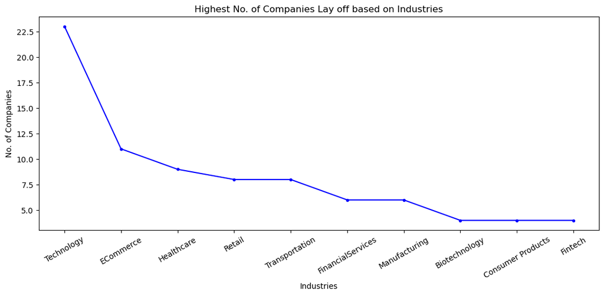

```python
plt.figure(figsize=(13,5))

plt.xticks(rotation=30, horizontalalignment="center")

plt.title("Highest No. of Companies Lay off based on Industries")

plt.xlabel('Industries')

plt.ylabel('No. of Companies')

plt.plot(top, 'b.-')
```

```python
# Grouping by industry and sorting the highest values and finding the unique values to plot the box plot
box = data.groupby(["Industry","Layoff"], as_index=False)['Layoff'].mean()
box1 = box.sort_values(by=['Layoff'], ascending=False)
box1 = box1.head(15)
```

```
[Text(0.5, 0, '')]
```

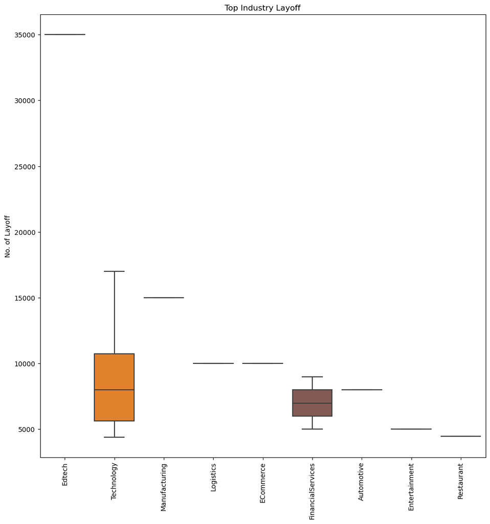

```python
plt.gcf().set_size_inches(12, 12)

plt.xticks(rotation=90, horizontalalignment="center")

ax = sns.boxplot(x ='Industry', y='Layoff', data=box1)
plt.title("Top Industry Layoff")

plt.xlabel('Industry')
plt.ylabel('No. of Layoff')
ax.set(xlabel=None)
```

# Structured Data for comparing

```python
data = pd.read_csv(r'layoffs.csv')
data
```

|  | company | location | industry | total_laid_off | percentage_laid_off | date | stage | country | funds_raised |
| --- | --- | --- | --- | --- | --- | --- | --- | --- | --- |
| 0 | Swyftx | Brisbane | Crypto | 90.0 | 0.40 | 2022-12-05 | Unknown | Australia | NaN |
| 1 | OYO | Gurugram | Travel | 600.0 | NaN | 2022-12-03 | Series F | India | 4000.0 |
| 2 | HealthifyMe | Bengaluru | Fitness | 150.0 | NaN | 2022-12-03 | Series C | India | 100.0 |
| 3 | Bybit | Singapore | Crypto | NaN | 0.30 | 2022-12-03 | Unknown | Singapore | NaN |
| 4 | Cognyte | Tel Aviv | Security | 100.0 | 0.05 | 2022-12-02 | Unknown | Israel | NaN |
| ... | ... | ... | ... | ... | ... | ... | ... | ... | ... |
| 1727 | HopSkipDrive | Los Angeles | Transportation | 8.0 | 0.10 | 2020-03-13 | Unknown | United States | 45.0 |
| 1728 | Panda Squad | SF Bay Area | Consumer | 6.0 | 0.75 | 2020-03-13 | Seed | United States | 1.0 |
| 1729 | Tamara Mellon | Los Angeles | Retail | 20.0 | 0.40 | 2020-03-12 | Series C | United States | 90.0 |
| 1730 | EasyPost | Salt Lake City | Logistics | 75.0 | NaN | 2020-03-11 | Series A | United States | 12.0 |
| 1731 | Homebound | SF Bay Area | Real Estate | NaN | NaN | NaN | Unknown | United States | 128.0 |

1732 rows × 9 columns

```python
#Dropping the columns that are not place in our previous table
data.drop('percentage_laid_off',inplace=True, axis=1)
data.drop('funds_raised',inplace=True, axis=1)
data.drop('stage',inplace=True, axis=1)
data.drop('location',inplace=True, axis=1)
```

```python
#Removing Duplicate values in Company
df2 = data.drop_duplicates(keep='first')
```

```python
#Replacing ) in NaN Values
df2 = df2.replace(r'^\s*$', np.nan, regex=True)
df2["total_laid_off"]= pd.to_numeric(df2["total_laid_off"], errors='coerce').fillna(0)
```

```python
#Re-naming the column name according our prev table
df2.rename(columns = {'company':'Company', 'industry':'Industry', 'total_laid_off':'Layoff', 'date':'Date',
                              'country':'Country'}, inplace = True)
```

```python
#Re-arrange the column name according our prev table
new_cols = ["Date","Company","Industry","Country","Layoff"]
df2=df2[new_cols]
```

```python
#Dropping the values that are not useful due to lack of accurate data
df2.drop(df2[(df2['Layoff'] < 80)].index, inplace=True)
```

```python
data1 = df2.sort_values(by=['Layoff'], ascending=False)
```

```python
data1['Industry']= data1['Industry'].replace("Consumer", "Technology")
```

```python
data1
```

|  | Date | Company | Industry | Country | Layoff |
| --- | --- | --- | --- | --- | --- |
| 148 | 2022-11-09 | Meta | Technology | United States | 11000.0 |
| 85 | 2022-11-16 | Amazon | Retail | United States | 10000.0 |
| 1155 | 2020-07-30 | Booking.com | Travel | Netherlands | 4375.0 |
| 86 | 2022-11-16 | Cisco | Infrastructure | United States | 4100.0 |
| 1304 | 2020-05-06 | Uber | Transportation | United States | 3700.0 |
| ... | ... | ... | ... | ... | ... |
| 739 | 2022-06-29 | AvantStay | Travel | United States | 80.0 |
| 740 | 2022-06-29 | Qumulo | Data | United States | 80.0 |
| 756 | 2022-06-28 | StockX | Retail | United States | 80.0 |
| 1628 | 2020-03-30 | FabHotels | Travel | India | 80.0 |
| 1356 | 2020-04-28 | App Annie | Data | United States | 80.0 |

569 rows × 5 columns

```python
#Group by Industry and showing the sum of layoffs by each industry
grouped = data1.groupby('Industry')
group_industry=grouped['Layoff'].agg(np.sum)
group_industry=group_industry.sort_values(ascending=False)

group_industry.head(10)
```

```
Industry
Technology        27736.0
Transportation    26704.0
Retail            25694.0
Food              18319.0
Finance           16020.0
Real Estate       15053.0
Travel            14964.0
Healthcare        10175.0
Education          9424.0
Fitness            8566.0
Name: Layoff, dtype: float64
```

```python
focus = data1[["Industry","Layoff"]].sort_values(by=['Layoff'], ascending=False)
topfocus1 = focus.head(50)
```

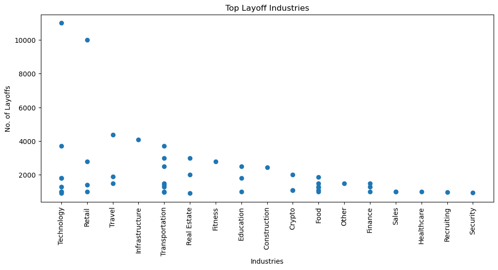

```python
plt.figure(figsize=(12,5))

plt.xticks(rotation=90, horizontalalignment="center")

plt.title("Top Layoff Industries")

#plt.plot(topfocus.Industry,topfocus.Layoff,'b.-')

plt.plot(topfocus1.Industry,topfocus1.Layoff,'o')

plt.xlabel('Industries')
plt.ylabel('No. of Layoffs')

plt.show()
```

The above graph is data on Top Layoff Industries collected from Kaggle. The X- axis represents the industries while the Y-axis represents the number of layoffs. The total data extracted from Kaggle was a whopping 1732 layoffs. I narrowed it down to the top 50. In this case, it is evident that Technology industry has the highest layoff followed by Technology, Retail, Travel.

```python
top_industry=data1.Industry.value_counts()
top1 =top_industry.head(10)
top1
```

```
Finance           62
Retail            51
Food              49
Transportation    49
Real Estate       43
Healthcare        42
Technology        37
Travel            29
Education         27
Crypto            21
Name: Industry, dtype: int64
```

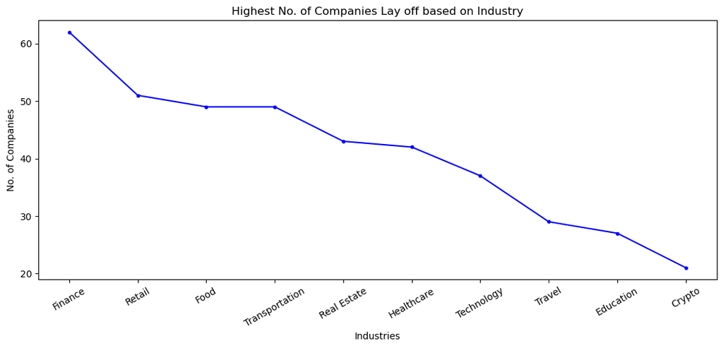

```python
plt.figure(figsize=(13,5))

plt.xticks(rotation=30, horizontalalignment="center")

plt.title("Highest No. of Companies Lay off based on Industry")

plt.xlabel('Industries')

plt.ylabel('No. of Companies')

plt.plot(top1, 'b.-')
```

```python
# Grouping by industry and sorting the highest values and finding the unique values to plot the box plot
box = data1.groupby(["Industry","Layoff"], as_index=False)['Layoff'].mean()
box1 = box.sort_values(by=['Layoff'], ascending=False)
box1=box1.head(15)
```

```
[Text(0.5, 0, '')]
```

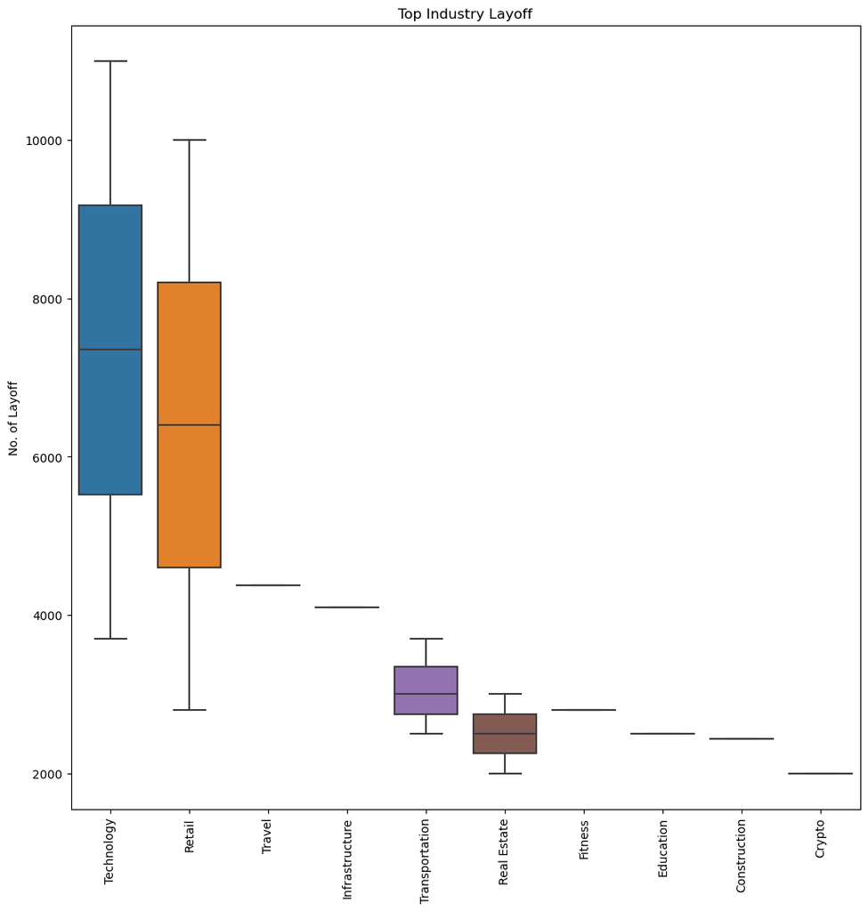

```python
plt.gcf().set_size_inches(12, 12)

plt.xticks(rotation=90, horizontalalignment="center")

ax = sns.boxplot(x ='Industry', y='Layoff', data=box1)

plt.title("Top Industry Layoff")

plt.xlabel('Industry')
plt.ylabel('No. of Layoff')

ax.set(xlabel=None)
```

The above graph is data onTop Industry Layoff based on Industry collected from Kaggle. The X- axis represents the industries while the Y-axis represents the number of layoffs. The total data extracted from Kaggle was a whopping 1732 layoffs. I narrowed it down to the top 10. In this case, it is evident that Technology industry has the highest layoff followed by Technology, Retail, Travel.

This code is creating a box plot to visualize the relationship between the "Industry" and "Layoff" columns in the "box1" dataframe.

- plt.gcf().set_size_inches(12, 12) is used to set the size of the chart
- plt.xticks(rotation=90, horizontalalignment="center") is used to rotate the x-axis labels by 90 degrees and align them horizontally in the center
- sns.boxplot(x ='Industry', y='Layoff', data=box1) is used to create a box plot, where x-axis is Industry and y-axis is Layoff. The data is passed in the form of dataframe box1.
- plt.title("Top Industry Layoff") is used to add a title to the chart
- plt.xlabel('Industry') is used to add a label to the x-axis
- plt.ylabel('No. of Layoff') is used to add a label to the y-axis
- ax.set(xlabel=None) is used to remove the x-axis label
- plt.show() is used to display the chart. This code is plotting box plot for top 10 industries with most Layoffs, where x-axis shows the industries and y-axis shows the number of layoffs. The chart's x-axis labels are also rotated by 90 degrees to make the labels more readable. The box plot gives the distribution of Layoffs in each Industry with the median, IQR and outliers. It can be useful for identifying the industries with most Layoffs and can be used for further analysis or decision making.

```python
#Webscraping Linkedin job. Jobs shown as of 10/1/2023
driver = webdriver.Chrome(executable_path=r'C:\Users\moham\Desktop\SIM SEM2.1\CM2015 - Data Programming\Midterm assignment\chromedriver.exe')
url_1 = 'https://www.linkedin.com/jobs/search?keywords=&location=Singapore&locationId=&geoId=102454443&sortBy=R&f_TPR=r86400&f_E=2&position=1&pageNum=0'
driver.get(url_1)
driver.implicitly_wait(10)
```

This code is using the Selenium webdriver to automate browser interactions and web scraping data from LinkedIn job search page.

- driver = webdriver.Chrome(executable_path=r'C:\Users\moham\Desktop\SIM SEM2.1\CM2015 - Data Programming\Midterm assignment\chromedriver.exe') is used to initialize the chrome driver. The executable path is provided to access the chrome browser.
- url_1 = 'https://www.linkedin.com/jobs/search?keywords=&location=Singapore&locationId=&geoId=102454443&sortBy=R&f_TPR=r86400&f_E=2&position=1&pageNum=0' is the URL of the LinkedIn job search page that is to be scraped.
- driver.get(url_1) is used to open the URL in the browser.
- driver.implicitly_wait(10) is used to wait for 10 seconds before the next step of execution, this is useful when the webpage is loading and we need to wait for all the elements to be loaded.

This code is opening the LinkedIn job search page in the chrome browser, with the search criteria being Jobs in Singapore, showing jobs as of 10/1/2023. It is also waiting for 10 seconds before moving to the next step of execution. This scraping technique can be used to collect job-related data from LinkedIn and can be used for data analysis or decision making.

```python
search = driver.find_elements(By.CLASS_NAME, "results-context-header__job-count")[0].text

num=pd.to_numeric(search)
num
```

```
908
```

This code is using the Selenium webdriver to extract the number of jobs found on the LinkedIn job search page, and then converts the extracted text to a numeric value.

- search = driver.find_elements(By.CLASS_NAME, "results-context-header**job-count")[0].text is used to find the element containing the number of jobs found on the page, using the class name "results-context-header**job-count". The text of the element is then extracted and stored in the variable "search".
- num=pd.to_numeric(search) is used to convert the extracted text to a numeric value and store it in the variable "num".

This code is extracting the number of jobs found on the LinkedIn job search page and converting it to a numeric value for further analysis or decision making. The variable 'num' will contain the number of jobs found on the LinkedIn job search page, it can be useful to analyze the job market or job trends.

```python
i=2
while i<=50:
    driver.execute_script("window.scrollTo(0, document.body.scrollHeight);")
    i=i+1

    try:
        button = find_element(By.XPATH,'//button[@aria-label="Load more results"]').click()
    except:
        pass
        time.sleep(5)

company_name = []
title_name = []
location_name = []

try:
    for j in range(num):
            company = driver.find_elements(By.CLASS_NAME, "base-search-card__subtitle")[j].text
            company_name.append(company)

    for i in range(num):
            title = driver.find_elements(By.CLASS_NAME, "base-search-card__title")[i].text
            title_name.append(title)

    for k in range(num):
            location = driver.find_elements(By.CLASS_NAME, "job-search-card__location")[k].text
            location_name.append(location)


except IndexError:
        print("Done")
```

This code is using the Selenium webdriver to automate scrolling down the LinkedIn job search page and loading more job results, then it is extracting the company name, job title and location of the jobs.

- i=2 and while i<=50: is used to scroll down the page 50 times, to load more job results on the page.
- driver.execute_script("window.scrollTo(0, document.body.scrollHeight);") is used to scroll down the page
- try: button = find_element(By.XPATH,'//button[@aria-label="Load more results"]').click() except: pass time.sleep(5) is used to click the "Load more results" button at the bottom of the page, if present
- company_name, title_name and location_name are empty lists that will be used to store the extracted data.
- try: is used to catch the exception when the end of the page is reached, and the loop is done
- for j in range(num): company = driver.find_elements(By.CLASS_NAME, "base-search-card__subtitle")[j].text company_name.append(company) is used to extract the company names of the jobs and store them in the "company_name" list.
- for i in range(num): title = driver.find_elements(By.CLASS_NAME, "base-search-card__title")[i].text title_name.append(title) is used to extract the job titles of the jobs and store them in the "title_name" list.
- for k in range(num): location = driver.find_elements(By.CLASS_NAME, "job-search-card__location")[k].text location_name.append(location) is used to extract the locations of the jobs and store them in the "location_name" list.
- except IndexError: print("Done") is used to catch the exception when the end of the page is reached, and the loop is done.

This code is scrolling down the LinkedIn job search page, loading more job results and extracting the company name, job title, and location of the jobs. The extracted data is stored in the "company_name", "title_name" and "location_name" lists, which can be used for further analysis or decision making. It can be useful for analyzing the job market or job trends, and also for identifying the companies and locations with the most job openings.

```python
company_final = pd.DataFrame(company_name,columns=["Company"])
title_final = pd.DataFrame(title_name,columns=["Title"])
location_final = pd.DataFrame(location_name,columns=["Location"])
table = company_final.join(title_final).join(location_final)
```

```python
table
```

|  | Company | Title | Location |
| --- | --- | --- | --- |
| 0 | Zagro Singapore Pte Ltd | Assistant Chemist | Singapore, Singapore |
| 1 | POWERQ TECHNOLOGY PTE LTD | Document Control Assistant | Singapore, Singapore |
| 2 | TMC Academy | Admin Assistant | Singapore, Singapore |
| 3 | DXC Technology | Business Analyst - Entry Level | Singapore, Singapore |
| 4 | NSL OilChem Waste Management Pte Ltd | Assistant Chemist | Singapore, Singapore |
| ... | ... | ... | ... |
| 903 | GREENLAND CHILDCARE @ SUMANG WALK PTE. LTD. | Childcare Chinese Teacher | Singapore, Singapore |
| 904 | ST Engineering | Senior Mechanical Engineer-Precision Alignment... | Singapore, Singapore |
| 905 | TELUS International AI Data Solutions | Flexible Work in Singapore - AI Community Surfer | Novena, Singapore |
| 906 | TELUS International AI Data Solutions | AI Community Surfer in Singapore (Freelance Work) | Paya Lebar, Singapore |
| 907 | UNSW | Associate Director, Chronos 14Carbon Cycle Fac... | Singapore, Singapore |

908 rows × 3 columns

```python
 table.to_csv('linkedin_sg.csv', index=False)
```

```python
df_sg = pd.read_csv('linkedin_sg.csv')
df_sg
```

|  | Company | Title | Location |
| --- | --- | --- | --- |
| 0 | Zagro Singapore Pte Ltd | Assistant Chemist | Singapore, Singapore |
| 1 | POWERQ TECHNOLOGY PTE LTD | Document Control Assistant | Singapore, Singapore |
| 2 | TMC Academy | Admin Assistant | Singapore, Singapore |
| 3 | DXC Technology | Business Analyst - Entry Level | Singapore, Singapore |
| 4 | NSL OilChem Waste Management Pte Ltd | Assistant Chemist | Singapore, Singapore |
| ... | ... | ... | ... |
| 903 | GREENLAND CHILDCARE @ SUMANG WALK PTE. LTD. | Childcare Chinese Teacher | Singapore, Singapore |
| 904 | ST Engineering | Senior Mechanical Engineer-Precision Alignment... | Singapore, Singapore |
| 905 | TELUS International AI Data Solutions | Flexible Work in Singapore - AI Community Surfer | Novena, Singapore |
| 906 | TELUS International AI Data Solutions | AI Community Surfer in Singapore (Freelance Work) | Paya Lebar, Singapore |
| 907 | UNSW | Associate Director, Chronos 14Carbon Cycle Fac... | Singapore, Singapore |

908 rows × 3 columns

```python
df_sg.info()
```

```
<class 'pandas.core.frame.DataFrame'>
RangeIndex: 908 entries, 0 to 907
Data columns (total 3 columns):
 #   Column    Non-Null Count  Dtype
---  ------    --------------  -----
 0   Company   908 non-null    object
 1   Title     908 non-null    object
 2   Location  908 non-null    object
dtypes: object(3)
memory usage: 21.4+ KB
```

```python
df_sg.describe()
```

|  | Company | Title | Location |
| --- | --- | --- | --- |
| count | 908 | 908 | 908 |
| unique | 554 | 777 | 11 |
| top | ST Engineering | Software Engineer | Singapore, Singapore |
| freq | 26 | 9 | 872 |

```python
top_company=df_sg.Company.value_counts()
top =top_company.head(15)
top
```

```
ST Engineering                           26
Randstad Singapore                       18
RECRUITPEDIA PTE. LTD.                   18
foodpanda                                17
UOB                                      12
RECRUITFLASH PTE. LTD.                   12
RANDSTAD PTE. LIMITED                    10
Singtel                                  10
RECRUIT EXPERT PTE. LTD.                 10
ISS FACILITY SERVICES PRIVATE LIMITED     9
Manpower Singapore                        9
APBA TG HUMAN RESOURCE PTE. LTD.          8
Recruit Lync Pte Ltd                      7
Halliburton                               6
KEPPEL SHIPYARD LIMITED                   6
Name: Company, dtype: int64
```

[figure not shown]

```python
plt.figure(figsize=(13,5))

plt.xticks(rotation=90, horizontalalignment="center")

plt.title("Companies offering Job")

plt.xlabel('Company Name')

plt.ylabel('Availablity Jobs')

plt.plot(top, 'b.-')
```

```python
top_title=df_sg.Title.value_counts()
top1 =top_title.head(15)
top1
```

```
Software Engineer                                 9
Senior Officer, Account Origination, COPC         8
Project Manager                                   8
Sales Manager                                     7
Associate Engineer                                6
Admin Assistant                                   5
Engineer                                          5
Project Engineer                                  5
Workplace Safety and Health Officer (EE_SG_AL)    5
Recruitment Consultant                            4
Associate Mechanical Engineer                     4
Driver                                            4
Preschool Teacher                                 4
Logistics Coordinator                             4
Mechanical Engineer                               3
Name: Title, dtype: int64
```

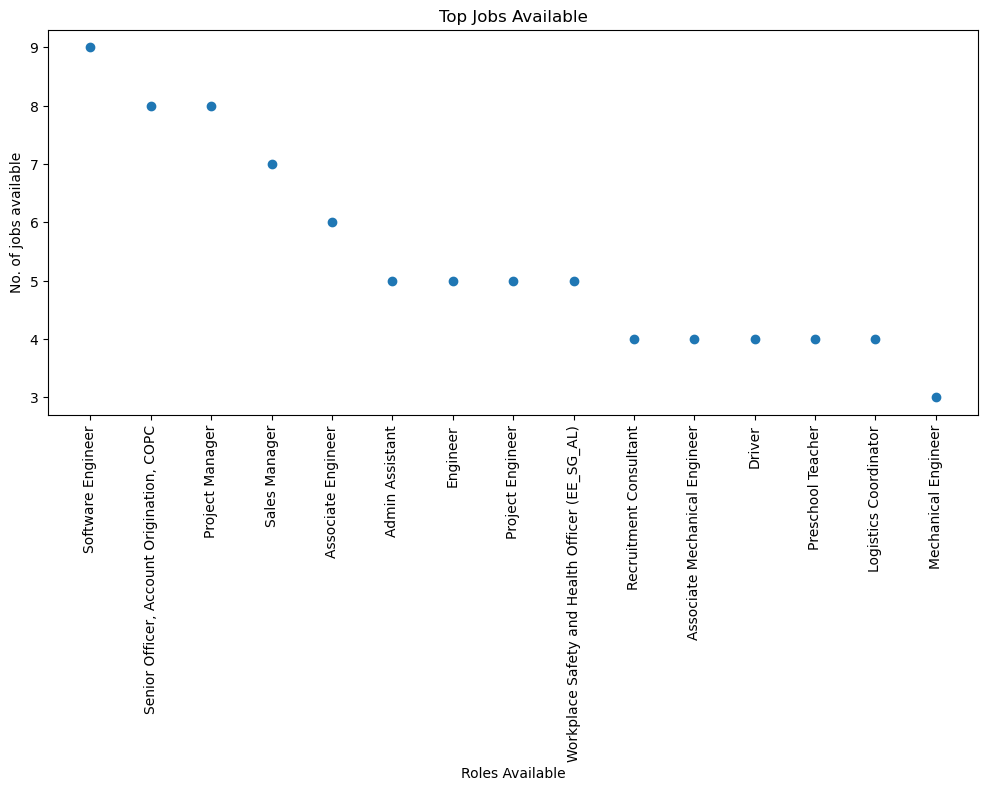

```python
plt.figure(figsize=(12,5))

plt.xticks(rotation=90, horizontalalignment="center")

plt.title("Top Jobs Available")

plt.plot(top1,'o')

plt.xlabel('Roles Available')
plt.ylabel('No. of jobs available')

plt.show()
```

```python
top_title=df_sg.Title.value_counts()
top1 =top_title.tail(15)
top1
```

```
Part Time Cleaner | Orchard| $12 per hour                                             1
Pharmaceuticals Process Engineer                                                      1
Telemarketing Specialist (Salary: $3,500/Banking/High Commission) - CODE: GL          1
Guest Relations Agent                                                                 1
Analyst (Electricity Bidding & Trading)                                               1
RECEPTIONIST | UP TO $3.5K | IMMEDIATE                                                1
HR Specialist (Talent Management and Engagement)                                      1
Salesforce Administrator, Commercial (APAC)                                           1
PURCHASING OFFICER                                                                    1
Baker                                                                                 1
Driver (Class 4) Night shift                                                          1
(B) Electrical Service Technician - Pasir Panjang (No Exp Req)                        1
Electronics Engineer                                                                  1
QA Engineer II, APAC                                                                  1
Associate Director, Chronos 14Carbon Cycle Facility -Associate Professor (Level D)    1
Name: Title, dtype: int64
```

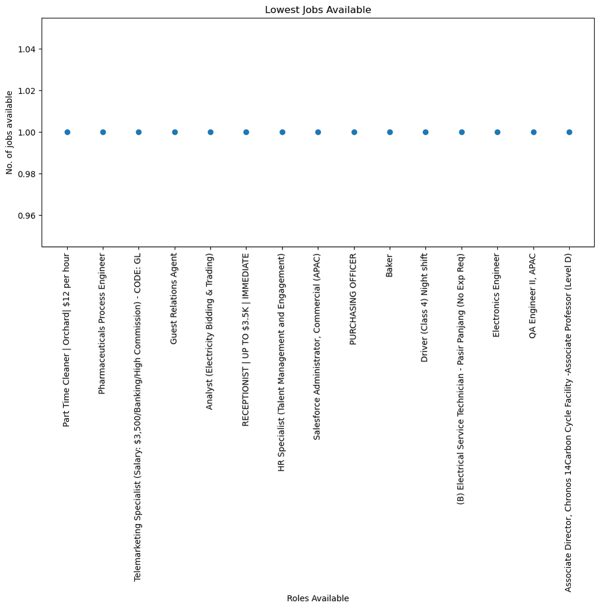

```python
plt.figure(figsize=(12,5))

plt.xticks(rotation=90, horizontalalignment="center")

plt.title("Lowest Jobs Available")

plt.plot(top1,'o')

plt.xlabel('Roles Available')
plt.ylabel('No. of jobs available')

plt.show()
```

# 6.1 Summary

In conclusion, it is evident that the technology industry suffered a greater impact in comparison to the other industries during the inflation period in 2022, resulting in the large layoff of employees from the technological companies. The data sets from Kaggle and Intellizence clearly showed the relationships between the increase in layoffs and the industry that was impacted by it the most.

While the datasets allowed us to understand which industry was affected the most during the inflation period, it will be useful to explore more on how this can be overcome. While linked-in provides a short-term solution for lay-off employees to look into, it will be more useful and efficient to find out through other job sites as to what are the more popular jobs and industries employees can join instead of just one. On top of that, the limitations can also be looked into for a more compact analysis.

# 7.1 Resources used

- [1] Subhani, C. (2022, October 27). Inflation in Singapore will stay high next year even as pace of economic growth slows: MAS. The Straits Times. https://www.straitstimes.com/business/inflation-in-singapore-will-stay-high-next-year-even-as-pace-of-economic-growth-slows-mas
- [2] Khieng Yuit, C. (2022, October 27). Spikes in global energy, food prices drive inflationary pressures in S’pore. The Straits Times. https://www.straitstimes.com/business/spikes-in-global-energy-food-prices-drive-inflationary-pressures-in-s-pore
- [3] Kaggle: Your Machine Learning and Data Science Community. (n.d.). https://www.kaggle.com/
- [4] Intellizence. (2021, October 7). About Intellizence | Intellizence. Intellizence |. https://intellizence.com/about-intellizence/ -
- [5] LinkedIn Singapore: Log In or Sign Up. (n.d.). LinkedIn. https://sg.linkedin.com/
- [6] Best Job Search Websites of 2023. (2023, January 13). The Balance. https://www.thebalancemoney.com/top-best-job-websites-2064080 Data
- [7] https://intellizence.com/insights/layoff-downsizing/leading-companies-announcing-layoffs-and-hiring-freezes/
- [8] https://www.kaggle.com/datasets/swaptr/layoffs-2022